# Loading Data into R

This is **Tutorial 2.4** from the ESL course taught at the Faculty of Informatics and Information Technologies, Slovak University of Technology in Bratislava.

The course loosely follows the book *An* *Introduction to Statistical Learning with Applications in R*[^1], while also drawing inspiration from Hadley Wickham’s *Advanced R*[^2]. You may notice small insights borrowed from these two excellent books here and there because they set a remarkably high standard for beginners, and they’re very hard to surpass.

| Version | Last Edit | Changes |
| --- | --- | --- |
| 2026.1 | 12-2-2026 | Minor text changes. |

This tutorial is part of your pre‑study preparation. Make sure you’re confident with the material by the end of week 2. The ESL labs and hands‑on exercises use R and the tidyverse throughout, so these skills are essential for working through the course effectively.

### Motivation

Rectangular data are a staple of machine learning and data analysis, consisting of rows and columns that create a structured, tabular format. Each row typically represents an observation or a data point, while each column corresponds to a specific variable or attribute.

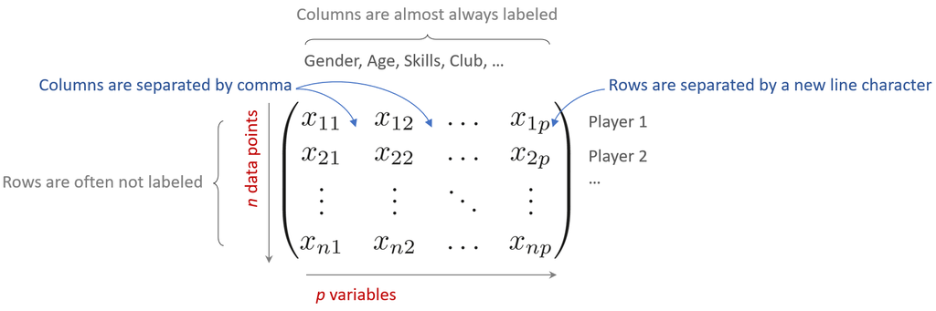

To separate the rows and columns, delimiters such as tabs, commas, semicolons, or other characters are used, ensuring clarity and organization. The rows are usually separated by a new line character, while columns within a row are divided by the chosen delimiter.

An essential characteristic of rectangular data is that all rows and columns must be of the same length, thus giving the data its typical rectangular shape. This structure allows for efficient data manipulation, analysis, and visualization, making it an ideal format for machine learning tasks and various analytical processes.

### Connecting Scenarios to Data

Rectangular data are commonly stored in CSV, TSV, or TXT files, and Excel sheets. They’re super easy to import into R using various functions from the **readr** and **readxl** packages. Once you’ve got your data in R, you can represent it using different data structures like arrays, matrices, data frames, lists, and tibbles. Each of these has its own strengths and weaknesses, so it’s worth thinking about which one suits your needs best.

- For numerical operations, matrices and arrays are your go-to. They’re efficient and straightforward for handling numerical data.
- On the other hand, if you’re dealing with more complex, multimodal data, list-based data frames and tibbles might be the better option. They’re great for mixed-type data and offer more flexibility.

In the following summary, we’ll give you some tips on the strengths and weaknesses of these data structures, so you can choose the best option for your needs.

|  | Description | Use Case | Strengths | Weaknesses |
| --- | --- | --- | --- | --- |
| **Arrays** | Multi-dimensional generalization of vectors capable of holding elements of the same type across multiple dimensions. | Useful for representing data with mode than 2 dimensions, such as 3D arrays for image data or multi-dimensional scientific data. | Can handle multi-dimensional data efficiently. Ideal for mathematical computations. | Limited to single data type. Managing high-dimensional arrays can be complex. |
| **Matrices** | Two-dimensional arrays where each element must be of the same type. Often used for mathematical computations. | Suitable for matrix operations, linear algebra and statistical calculations. | Efficient for matrix and linear algebra operations. Easy to subset and manipulate. | Limited to two dimensions. Cannot hold heterogeneous data types. |
| **Lists** | Versatile data structures that can hold elements of different data types. | Perfect for storing heterogeneous data, such as results from various analyses, hierarchical data, or mixed-type datasets. | Highly flexible and can store diverse types of elements. Powerful for complex data structures. | Less efficient for vectorized operations. More complex to manipulate compared to vectors. |
| **Data Frames** | Special type of list where each element (column) is a vector of the same length. Designed to store tabular data with different types in each column. | Ideal for structured datasets like FIFA22, experimental data, or financial results. | Can hold mixed data types. Well-integrated with data manipulation functions in R. Familiar spreadsheet-like interface. | Less efficient than matrices for purely numerical operations. Requires additional memory for large datasets. |
| **Tibbles** | Modern version of data frames with enhanced features for data manipulation. | Best for use in tidyverse workflows and handling large datasets. | Improved printing, subsetting, and compatibility with tidyverse functions. Prevents common pitfalls associated with data frames. | Requires familiarity with the tibble package. May need conversion when integrating with non-tidyverse code. |

### The Readr Package

The readr package is essential for importing data. It offers numerous functions that start with `read_` (and corresponding `write_` functions). Among them, the `read_delim()` function stands out as one of the most versatile and generic. It allows you to read flat file data using any delimiter. This function is particularly valuable because it supports reading common file types such as CSV and TSV, while also offering the flexibility to handle other delimiters as needed.

For instance, `read_csv()` is a variant of the `read_delim()` function dedicated for reading comma-separated fields in files that have a new line character `\n` separating lines.

In a similar vein, `read_csv2()` is a variant that is tailored for files with semicolons as field separators and commas for decimal points, a format often found in Eastern Europe. The `read_tsv()` function allows for reading tab-delimited formats whilst `read_table()` and `read_fwf()` read a fixed width table.

### Configuring the Working Directory

Before loading data into R, it is custom to set up a *working directory* so you won’t need to retype full path every time a file is requested. Setting up working directory should be normally your first priority and it needs to be defined only once.

```r
setwd("... here comes the path...")
```

R typically sets up in your personal document folder. If you are unsure where it is, use `getwd()` function to retrieve the path of current working directory where R will look for files to read and where it will save outputs.

### Listing Files

The `list.files()` and `list.dir()` functions generate a character vector containing the names of files and, optionally, directories within a specified directory. Let’s use these functions to find out how many `player_` files are stored inside the folder.

```r
library(tidyverse)

setwd("~/OneDrive/Documents/The Elements of Statistical Learning/Data/FIFA.22.Original.Data/")
list.files(include.dirs = FALSE, full.names = FALSE, all.files = FALSE)
```

```
##  [1] "female_players_16.csv" "female_players_17.csv" "female_players_18.csv"
##  [4] "female_players_19.csv" "female_players_20.csv" "female_players_21.csv"
##  [7] "female_players_22.csv" "players_15.csv"        "players_16.csv"
## [10] "players_17.csv"        "players_18.csv"        "players_19.csv"
## [13] "players_20.csv"        "players_21.csv"        "players_22.csv"
```

```r
list.dirs()
```

```
## [1] "."
```

In our little example, `list.files()` returns 15 file names and no directory. You can customize the output through various arguments, such as `pattern` to filter files by name, `all.files` to include hidden files, and `full.names` to return the full paths.

**Task 1:** Update the previous R code so that `list.files()` returns only files containing “*player*” sub-string inside their file names.

### Loading Files with `read_csv()`

Knowing which files you may chose from, let’s load one of them with `read_csv()` to understand the data structure generated through the process.

```r
setwd("~/OneDrive/Documents/The Elements of Statistical Learning/Data/FIFA.22.Original.Data/")
data <- read_csv("players_22.csv")
```

The `read_csv()` function imports data from a CSV file named `players_22.csv` into R. The function reads data and stores it as a data frame. Here’s a brief breakdown of what happens implicitly:

1. File reading: The function reads the contents of the CSV file.
2. Data parsing: It parses the data, interpreting the commas as delimiters between columns.
3. Tibble creation: The parsed data is then stored in a data frame, which allows for easy manipulation and analysis.

**Task 2:** Reload `players_22.csv` into R, but this time, use the `read.csv()` function instead of `read_csv()`. Since `read.csv()` is part of base R, no additional packages are needed. Compare the default behaviors of both functions and create a table summarizing the main differences, particularly focusing on how missing values and different column types are handled.

| read.csv() | read_csv() |
| --- | --- |
| Returns a data frame. | Returns a tibble. |
| … | … |

**Task 3:** Load `players_22.csv` using the following code. Before executing it, consider what will happen to the column names. Will they be retained in the data frame?

```r
read_csv("players_22.csv", col_names = FALSE)
```

**Task 4:** Use the `t()` function to transpose data frame created with `read.csv(players_22.csv)`. Consider what happened to the column names. Are they still present in the data?

**Task 5:** Read two arbitrary files from the FIFA22 directory, say `players_21.csv` and `players_22.csv` and combine them into single data frame. Do not use loops (which you haven’t learned anyway).

**Task 6:** Modify the current command involving `read_csv()` to import `short_name` and all fields which name include `skill`.

### Missing Values

The `na` parameter in the `read_csv()` function in R is used to specify which strings should be treated as missing values (NA) when importing data. By default, `read_csv()` treats empty fields as missing values, but you can customize this behavior by providing a vector of strings to the `na` parameter.

**Task 7:** Modify `read_csv()` command from the previous examples so that recognizes both `NA` and an empty strings `""` as missing values.

### The `attach()` Function

The `attach()` function is used to make the variables in a loaded data frame accessible without having to reference the data frame explicitly. This can simplify your code when you need to work with many variables from the same data frame and you do not want to refer to that data frame by name each time a variable is called. A complementary function to `attach()` is — not surprisingly — `detach()`.

Here’s how you can use it:

```r
attach(data)
head(skill_dribbling) #Normally you need to type: head(data$skill_dribbling)
```

```
## [1] 96 85 88 95 88 12
```

```r
detach(data)
```

Notice that while `attach()` can be convenient, it can also lead to confusion if not used carefully, especially in larger scripts. It’s often better to use the `$` operator for clarity.

### The `View()` Function

```r
data
```

```
## # A tibble: 19,239 × 110
##    sofifa_id player_url  short_name long_name player_positions overall potential
##        <dbl> <chr>       <chr>      <chr>     <chr>              <dbl>     <dbl>
##  1    158023 https://so… L. Messi   Lionel A… RW, ST, CF            93        93
##  2    188545 https://so… R. Lewand… Robert L… ST                    92        92
##  3     20801 https://so… Cristiano… Cristian… ST, LW                91        91
##  4    190871 https://so… Neymar Jr  Neymar d… LW, CAM               91        91
##  5    192985 https://so… K. De Bru… Kevin De… CM, CAM               91        91
##  6    200389 https://so… J. Oblak   Jan Oblak GK                    91        93
##  7    231747 https://so… K. Mbappé  Kylian M… ST, LW                91        95
##  8    167495 https://so… M. Neuer   Manuel P… GK                    90        90
##  9    192448 https://so… M. ter St… Marc-And… GK                    90        92
## 10    202126 https://so… H. Kane    Harry Ka… ST                    90        90
## # ℹ 19,229 more rows
## # ℹ 103 more variables: value_eur <dbl>, wage_eur <dbl>, age <dbl>, dob <date>,
## #   height_cm <dbl>, weight_kg <dbl>, club_team_id <dbl>, club_name <chr>,
## #   league_name <chr>, league_level <dbl>, club_position <chr>,
## #   club_jersey_number <dbl>, club_loaned_from <chr>, club_joined <date>,
## #   club_contract_valid_until <dbl>, nationality_id <dbl>,
## #   nationality_name <chr>, nation_team_id <dbl>, nation_position <chr>, …
```

To work interactively with all content that data frame has to offer, you can use the `View()` function. It opens a spreadsheet-style data viewer within RStudio.

[figure not shown]

```r
View(data[,c(1,3:9)])
```

### `head()` and `tail()`

The `head()` and `tail()` functions are used to view the beginning and the end of a data frame or tibble, respectively. The `head()` function displays the first few rows of a data frame or tibble. By default, it shows the first 6 rows, but you can customize the number of rows displayed by specifying the `n` parameter.

```r
head(data)
```

```
## # A tibble: 6 × 110
##   sofifa_id player_url   short_name long_name player_positions overall potential
##       <dbl> <chr>        <chr>      <chr>     <chr>              <dbl>     <dbl>
## 1    158023 https://sof… L. Messi   Lionel A… RW, ST, CF            93        93
## 2    188545 https://sof… R. Lewand… Robert L… ST                    92        92
## 3     20801 https://sof… Cristiano… Cristian… ST, LW                91        91
## 4    190871 https://sof… Neymar Jr  Neymar d… LW, CAM               91        91
## 5    192985 https://sof… K. De Bru… Kevin De… CM, CAM               91        91
## 6    200389 https://sof… J. Oblak   Jan Oblak GK                    91        93
## # ℹ 103 more variables: value_eur <dbl>, wage_eur <dbl>, age <dbl>, dob <date>,
## #   height_cm <dbl>, weight_kg <dbl>, club_team_id <dbl>, club_name <chr>,
## #   league_name <chr>, league_level <dbl>, club_position <chr>,
## #   club_jersey_number <dbl>, club_loaned_from <chr>, club_joined <date>,
## #   club_contract_valid_until <dbl>, nationality_id <dbl>,
## #   nationality_name <chr>, nation_team_id <dbl>, nation_position <chr>,
## #   nation_jersey_number <dbl>, preferred_foot <chr>, weak_foot <dbl>, …
```

Similarly fares the `tail()` function. Like `head()`, it displays 6 rows by default but allows customization with the `n` parameter.

### The `slice()` Function

If you want to print only selected lines from a tibble, use the `slice()` function from the **dplyr** package. Unlike `head()` and `tail()`, which only display the first or last few rows, `slice()` allows you to select specific row numbers to print. This makes it easy to extract and view precise subsets of your data frame.

Here’s an example of how to use `slice()`:

```r
slice(data, c(1:3, 10, 20))
```

```
## # A tibble: 5 × 110
##   sofifa_id player_url   short_name long_name player_positions overall potential
##       <dbl> <chr>        <chr>      <chr>     <chr>              <dbl>     <dbl>
## 1    158023 https://sof… L. Messi   Lionel A… RW, ST, CF            93        93
## 2    188545 https://sof… R. Lewand… Robert L… ST                    92        92
## 3     20801 https://sof… Cristiano… Cristian… ST, LW                91        91
## 4    202126 https://sof… H. Kane    Harry Ka… ST                    90        90
## 5    212622 https://sof… J. Kimmich Joshua W… CDM, RB               89        90
## # ℹ 103 more variables: value_eur <dbl>, wage_eur <dbl>, age <dbl>, dob <date>,
## #   height_cm <dbl>, weight_kg <dbl>, club_team_id <dbl>, club_name <chr>,
## #   league_name <chr>, league_level <dbl>, club_position <chr>,
## #   club_jersey_number <dbl>, club_loaned_from <chr>, club_joined <date>,
## #   club_contract_valid_until <dbl>, nationality_id <dbl>,
## #   nationality_name <chr>, nation_team_id <dbl>, nation_position <chr>,
## #   nation_jersey_number <dbl>, preferred_foot <chr>, weak_foot <dbl>, …
```

### Footnotes

[^1]: James, Gareth, Daniela Witten, Trevor Hastie, and Robert Tibshirani. 2021. *An Introduction to Statistical Learning: With Applications in R*. 2nd ed. New York: Springer.
[^2]: Wickham, Hadley. 2019. *Advanced R*. 2nd ed. Boca Raton, FL: CRC Press.